# Week 1 Lab. Describing Data

Craig Enders

Friday October 2

■ data frame name ■ numeric variable ■ categorical variable (factor) ■ raw data file name

# The Data

The data for this lab come from a study of uveal melanoma, a rare eye cancer that presents potential vision loss and life threat. This prospective, longitudinal study interrogated the predictive utility of visual impairment, as moderated by optimism and pessimism, on depressive symptoms in 299 adults undergoing diagnostic evaluation (MacDonald, Jorge-Miller, Enders, McCannel, Beran, & Stanton, 2021, *Health Psychology*, 40, 408–417).

Based on a diagnostic clinical evaluation for a possible intraocular malignancy, participants were classified as having malignant or nonmalignant diagnoses. Three numeric variables are of primary interest.

**Depressive symptoms.** The Center for Epidemiologic Studies Depression Scale (CES-D) is a 20-item inventory that asks people to rate how often they experience depressive symptoms such as restless sleep, poor appetite, and feeling lonely. Each item is scored 0 (rarely or none of the time) to 3 (most or all of the time), so the summed score ranges from 0 to 60. Higher scores indicate greater depressive symptoms, and an established cutoff for clinically elevated symptoms is 16 or above.

**Dispositional optimism.** The Life Orientation Test–Revised (LOT-R) optimism subscale consists of three items that ask people to rate their tendency to expect positive outcomes in life, each on a five-point scale from 0 (I disagree a lot) to 4 (I agree a lot). The summed score ranges from 0 to 12.

**Visual impairment.** The Measure of Outcome in Ocular Disease vision subscale (MOOD-V) is a 13-item measure. Scores were summed and transformed to a 0–100 scale, with higher scores indicating greater impairment.

| Variable | Description | Scale |
| --- | --- | --- |
| `Participant` | Participant identifier | 1 to 299 |
| `Diagnosis` | Result of the diagnostic biopsy | 0 = Non-malignant, 1 = Malignant |
| `Age` | Age in years | 19 to 91 |
| `Male` | Respondent sex | 0 = Female, 1 = Male |
| `Comorbids` | Number of medical comorbidities | 0 = none, 1 = one, 2 = two or more |
| `Optimism` | LOT-R optimism subscale (sum of 3 items) | 0 to 12 |
| `Depression` | CES-D depressive symptoms (sum of 20 items) | 0 to 60 |
| `VisImpair` | MOOD-V visual impairment (transformed) | 0 to 100 |

Notice that the categorical variables are entered as numbers, not labels: `Diagnosis` and `Male` are coded 0 and 1, and `Comorbids` is coded 0, 1, and 2. In the raw file there is nothing to tell R that these codes are categories rather than quantities, which is why the labels in the table above matter. A later step uses the `factor()` function to attach those labels to the data.

# Preliminaries: Loading Packages

R’s built-in functions handle basic statistics, but the displays in this lab come from three add-on packages. `library()` makes a package’s functions available for the current session; it has to be run each time you open R, and it assumes the package was installed beforehand (see the Week 0 R Package Installation Script).

```r
# ggplot2 produces the histograms, density plots, and bar plots
library(ggplot2)

# psych provides the describe() function for descriptive statistics
library(psych)

# summarytools provides dfSummary() and freq() for data summaries
library(summarytools)

# rstudioapi talks to RStudio, used here to find the folder that contains this script
library(rstudioapi)
```

# Importing Data

There are two ways to get the data file into R. The document uses the first; the second is shown for reference because it is the one you will use with data files stored on your own computer.

Both methods call `read.csv()` with `stringsAsFactors = TRUE`, the same call used in the assignments. The argument converts any text column to a factor, but this file has none: the categorical variables `Diagnosis` and `Male` are stored as 0/1 codes and `Comorbids` as 0/1/2 codes, so every column, including these, is read as numeric. R will happily compute a mean of `Diagnosis` unless told otherwise. The next section converts those codes to factors by hand.

## Option 1: Read From the Course Website

The data file lives on the course GitHub site. Store the web address in an object, then hand that address to `read.csv()`. Keeping the address in its own object is a small convenience: if the file moves, only one line changes.

```r
# store the web address of the raw data file
filepath <- "https://raw.githubusercontent.com/craigenders/psych250a/main/data/Cancer.csv"

# read the file at that address into a data frame named Cancer
Cancer <- read.csv(filepath, stringsAsFactors = TRUE)
```

## Option 2: Read From the Folder That Contains the Script

When a data file is saved in the same folder as your R script, you can point R at that folder and then refer to the file by name alone. The rstudioapi package asks RStudio for the path of the script you are currently editing; `dirname()` strips the file name to leave the folder, and `setwd()` makes that folder R’s working directory. `getwd()` prints the working directory so you can confirm it landed where you expected. After that, `read.csv()` needs only the file name.

This block is displayed but not run, because a knitted document has no script to locate. Run it from an R script saved next to `Cancer.csv`. In the lab script the same lines are commented out; remove the leading `#` to use them.

```r
# set the working directory to the folder that contains this script
setwd(dirname(getActiveDocumentContext()$path))

# print the working directory to confirm the location
getwd()

# read Cancer.csv from the working directory into a data frame named Cancer
Cancer <- read.csv("Cancer.csv", stringsAsFactors = TRUE)
```

# Converting Categorical Variables to Factors

R does not know that `Diagnosis` and `Male` are categorical; it sees two numeric columns of 0s and 1s. Left that way, plotting and summary functions would treat them as continuous variables. The `factor()` function converts a numeric column to a *factor*, R’s term for a categorical variable. The `levels` argument lists the codes in the data, and the `labels` argument gives each code a name; the two are matched in order, so 0 becomes the first label and 1 the second.

The conversion replaces each column in place. Once a column is a factor, re-running `factor()` on it with the same `levels` would produce all `NA` values, because the codes no longer exist, so run this block only once after reading the data.

```r
# convert Diagnosis from 0/1 codes to a factor with descriptive labels
Cancer$Diagnosis <- factor(Cancer$Diagnosis,
                           levels = c(0, 1),
                           labels = c("Non-malignant", "Malignant"))

# convert Male from 0/1 codes to a factor with descriptive labels
Cancer$Male <- factor(Cancer$Male,
                      levels = c(0, 1),
                      labels = c("Female", "Male"))

# print the first few rows to confirm the labels replaced the codes
head(Cancer)
```

```
  Participant     Diagnosis Age   Male Comorbids Optimism Depression VisImpair
1           1 Non-malignant  43 Female         1        7         42        52
2           2 Non-malignant  25 Female         1        6          3        43
3           3 Non-malignant  55 Female         0       10          8        61
4           4 Non-malignant  46   Male         0        8         22        50
5           5 Non-malignant  73   Male         2       12          3        24
6           6     Malignant  60 Female         1       12         10        30
```

# Summarizing Data

Before computing anything, look at the whole data frame at once. `dfSummary()` from the summarytools package produces one row per variable showing its type, a compact summary of its values, a small graph of its distribution, and the number of valid and missing cases. It is the fastest way to confirm that a file read in correctly and to notice anything odd — a variable stored as the wrong type, an impossible value, unexpected missingness — before it contaminates later analyses. In the HTML version of this lab, the table is handed to `print()` with `method = "render"` so that it displays as formatted HTML; that wrapper is not needed in your own documents.

```r
# overview of every variable in the data frame
print(dfSummary(Cancer), method = "render")
```

Data Frame Summary

Cancer

**Dimensions**: 299 x 8  
**Duplicates**: 0

| **No** | **Variable** | **Stats / Values** | **Freqs (% of Valid)** | **Graph** | **Valid** | **Missing** |
| --- | --- | --- | --- | --- | --- | --- |
| 1 | Participant [integer] | Mean (sd) : 150 (86.5) min ≤ med ≤ max: 1 ≤ 150 ≤ 299 IQR (CV) : 149 (0.6) | 299 distinct values (Integer sequence) |  | 299 (100.0%) | 0 (0.0%) |
| 2 | Diagnosis [factor] | 1. Non-malignant 2. Malignant | 192 ( 64.2% ) 107 ( 35.8% ) |  | 299 (100.0%) | 0 (0.0%) |
| 3 | Age [integer] | Mean (sd) : 59 (13.9) min ≤ med ≤ max: 19 ≤ 60 ≤ 91 IQR (CV) : 17.5 (0.2) | 61 distinct values |  | 299 (100.0%) | 0 (0.0%) |
| 4 | Male [factor] | 1. Female 2. Male | 138 ( 46.2% ) 161 ( 53.8% ) |  | 299 (100.0%) | 0 (0.0%) |
| 5 | Comorbids [integer] | Mean (sd) : 0.9 (0.7) min ≤ med ≤ max: 0 ≤ 1 ≤ 2 IQR (CV) : 1 (0.8) | 0 : 91 ( 30.4% ) 1 : 135 ( 45.2% ) 2 : 73 ( 24.4% ) |  | 299 (100.0%) | 0 (0.0%) |
| 6 | Optimism [integer] | Mean (sd) : 8.6 (2.9) min ≤ med ≤ max: 0 ≤ 9 ≤ 12 IQR (CV) : 4 (0.3) | 13 distinct values |  | 299 (100.0%) | 0 (0.0%) |
| 7 | Depression [integer] | Mean (sd) : 14.9 (11.4) min ≤ med ≤ max: 0 ≤ 11 ≤ 60 IQR (CV) : 13 (0.8) | 50 distinct values |  | 299 (100.0%) | 0 (0.0%) |
| 8 | VisImpair [integer] | Mean (sd) : 42 (15.1) min ≤ med ≤ max: 10 ≤ 40 ≤ 90 IQR (CV) : 20.5 (0.4) | 66 distinct values |  | 299 (100.0%) | 0 (0.0%) |

Generated by summarytools 1.1.5 ([R](https://www.r-project.org/) version 4.6.1)  
2026-10-16

# Descriptive Statistics

`describe()` from the psych package computes the standard numeric summaries for every variable in a data frame: sample size, mean, standard deviation, median, trimmed mean, median absolute deviation, minimum, maximum, range, skewness, kurtosis, and the standard error of the mean. The skewness and kurtosis columns are the ones this lab returns to when interpreting distribution shape.

The `kurtosis` column reports *excess* kurtosis, not raw kurtosis. Raw kurtosis equals 3 for a normal distribution; `describe()` subtracts that 3, so a value of 0 indicates normal tail weight, positive values indicate heavier tails than the normal curve, and negative values indicate lighter tails.

Two cautions when reading this output. Factor variables (marked with an asterisk) are summarized as if their levels were the numbers 1, 2, …, so their means and standard deviations are not meaningful. And the `Participant` column is an identifier, so its statistics describe nothing about the sample.

```r
# descriptive statistics for every variable in the data frame
describe(Cancer)
```

```
            vars   n   mean    sd median trimmed    mad min max range  skew kurtosis   se
Participant    1 299 150.00 86.46    150  150.00 111.19   1 299   298  0.00    -1.21 5.00
Diagnosis*     2 299   1.36  0.48      1    1.32   0.00   1   2     1  0.59    -1.66 0.03
Age            3 299  58.99 13.94     60   59.47  11.86  19  91    72 -0.33    -0.15 0.81
Male*          4 299   1.54  0.50      2    1.55   0.00   1   2     1 -0.15    -1.98 0.03
Comorbids      5 299   0.94  0.74      1    0.93   1.48   0   2     2  0.10    -1.17 0.04
Optimism       6 299   8.56  2.95      9    8.87   2.97   0  12    12 -0.77    -0.16 0.17
Depression     7 299  14.85 11.44     11   13.12   7.41   0  60    60  1.46     1.97 0.66
VisImpair      8 299  42.04 15.11     40   41.29  14.83  10  90    80  0.44    -0.02 0.87
```

# Histograms and Kernel Density Plots

A histogram divides the range of a numeric variable into bins and draws a bar whose height reflects how many observations fall in each bin. A kernel density plot is a smoothed version of the same information: a continuous curve estimating the relative frequency of scores across the variable’s range. Overlaying the two lets you see both the raw counts and the underlying shape.

Every ggplot2 graph is built the same way, in layers joined by `+`:

- `ggplot(Cancer, aes(x = Depression))` names the data frame and maps the variable `Depression` to the horizontal axis. This line draws nothing by itself; it sets up the coordinate system that later layers draw on.
- `geom_histogram()` adds the bars.
- Inside `geom_histogram()`, `aes(y = after_stat(density))` changes the vertical axis from raw counts to density — the proportion of cases per unit of the horizontal axis. This rescaling is what allows a density curve to be drawn on the same axes; without it the curve would sit invisibly at the bottom of a count-scaled plot.
- `geom_density()` adds the smoothed curve.

## Depression Distribution

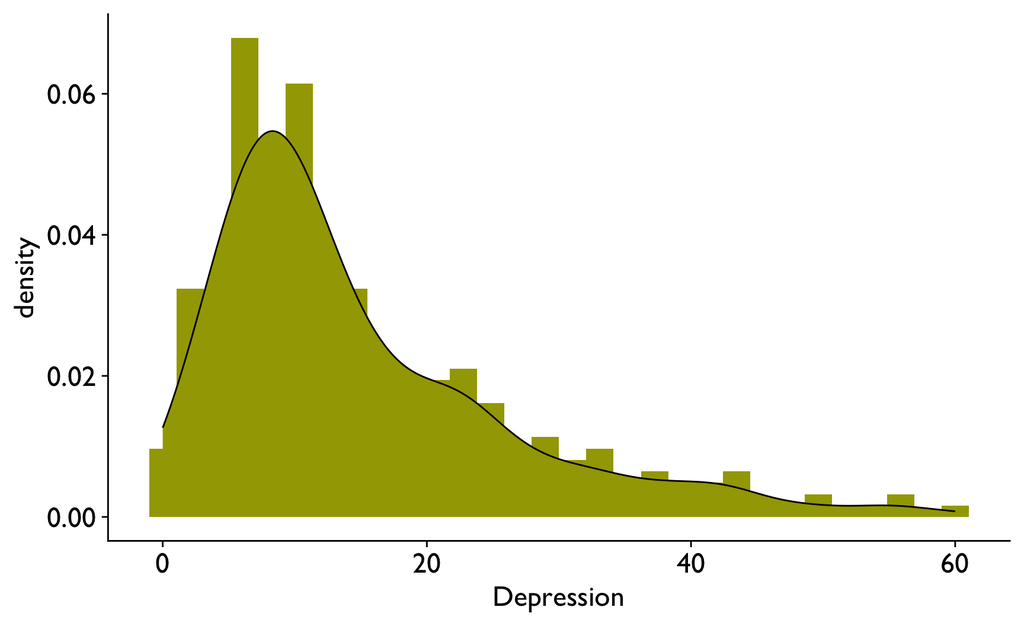

```r
# histogram with overlaid kernel density curve for Depression
ggplot(Cancer, aes(x = Depression)) +
  geom_histogram(aes(y = after_stat(density))) +
  geom_density()
```

## Optimism Distribution

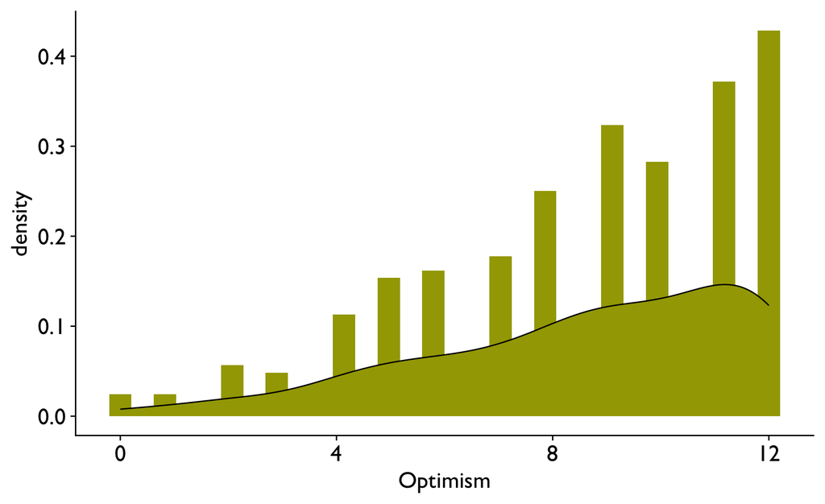

```r
# histogram with overlaid kernel density curve for Optimism
ggplot(Cancer, aes(x = Optimism)) +
  geom_histogram(aes(y = after_stat(density))) +
  geom_density()
```

## Visual Impairment Distribution

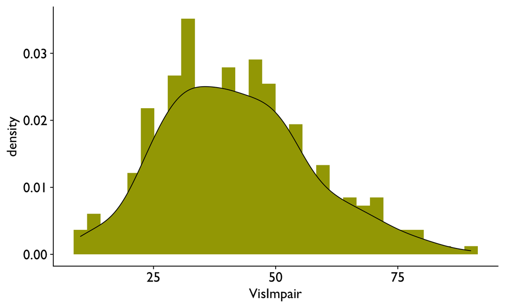

```r
# histogram with overlaid kernel density curve for VisImpair
ggplot(Cancer, aes(x = VisImpair)) +
  geom_histogram(aes(y = after_stat(density))) +
  geom_density()
```

# Distribution Plots by Group

To compare groups, draw the same histogram-plus-density display separately for each level of a categorical variable. Two additions to the code do this:

- `colour = Diagnosis` inside `aes()` maps the grouping variable to the outline color of the bars and curve, so each group is drawn in its own color and a legend is added automatically.
- `facet_wrap(~ Diagnosis)` splits the display into one panel per level of `Diagnosis`, placed side by side on identical axes. Identical axes are what make the panels comparable — a shift in location or a difference in spread is visible directly.

## Depression Distributions by Diagnosis

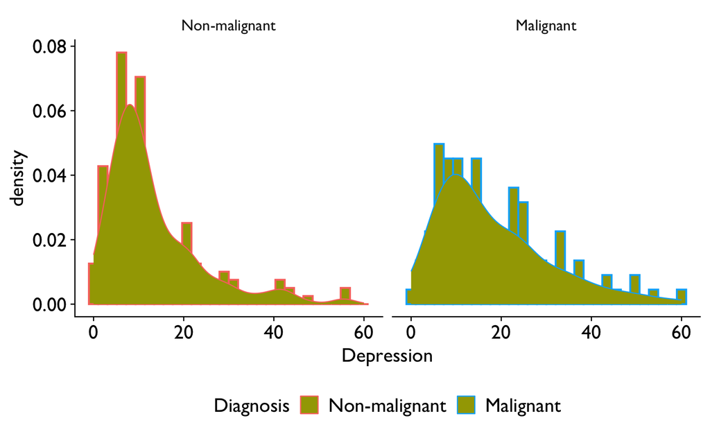

```r
# histogram with density curve for Depression, one panel per Diagnosis group
ggplot(Cancer, aes(x = Depression, colour = Diagnosis)) +
  geom_histogram(aes(y = after_stat(density))) +
  geom_density() +
  facet_wrap(~ Diagnosis)
```

## Optimism Distributions by Diagnosis

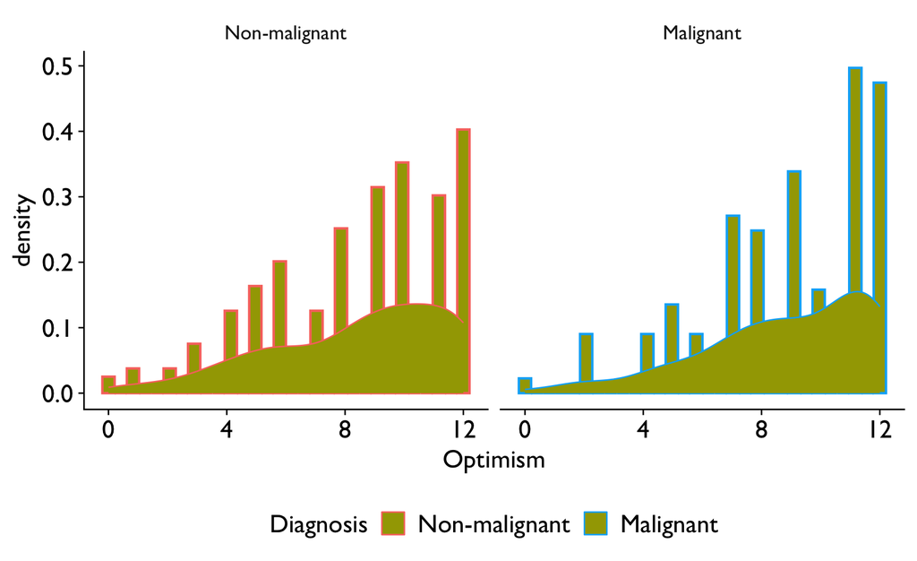

```r
# histogram with density curve for Optimism, one panel per Diagnosis group
ggplot(Cancer, aes(x = Optimism, colour = Diagnosis)) +
  geom_histogram(aes(y = after_stat(density))) +
  geom_density() +
  facet_wrap(~ Diagnosis)
```

# Frequency Distributions for Discrete Variables

For a variable with a small number of distinct values, a table listing each value with its count and percentage conveys the distribution exactly. `freq()` from the summarytools package produces that table, including cumulative percentages, for a single variable. The `$` operator extracts one column from the data frame; `Cancer$Diagnosis` is the `Diagnosis` variable by itself.

`freq()` works on factors such as `Diagnosis` and on numeric variables with few values such as `Optimism` and `Comorbids`.

```r
# frequency table for the categorical variable Diagnosis
print(freq(Cancer$Diagnosis), method = "render")
```

Frequencies

Cancer$Diagnosis

**Type**: Factor

| Diagnosis | Freq | Valid % | Valid % Cum. | Total % | Total % Cum. |
| --- | --- | --- | --- | --- | --- |
| Non-malignant | 192 | 64.21 | 64.21 | 64.21 | 64.21 |
| Malignant | 107 | 35.79 | 100.00 | 35.79 | 100.00 |
| <NA> | 0 |  |  | 0.00 | 100.00 |
| Total | 299 | 100.00 | 100.00 | 100.00 | 100.00 |

Generated by summarytools 1.1.5 ([R](https://www.r-project.org/) version 4.6.1)  
2026-10-16

```r
# frequency table for the 13-point Optimism scale
print(freq(Cancer$Optimism), method = "render")
```

Frequencies

Cancer$Optimism

**Type**: Integer

| Optimism | Freq | Valid % | Valid % Cum. | Total % | Total % Cum. |
| --- | --- | --- | --- | --- | --- |
| 0 | 3 | 1.00 | 1.00 | 1.00 | 1.00 |
| 1 | 3 | 1.00 | 2.01 | 1.00 | 2.01 |
| 2 | 7 | 2.34 | 4.35 | 2.34 | 4.35 |
| 3 | 6 | 2.01 | 6.35 | 2.01 | 6.35 |
| 4 | 14 | 4.68 | 11.04 | 4.68 | 11.04 |
| 5 | 19 | 6.35 | 17.39 | 6.35 | 17.39 |
| 6 | 20 | 6.69 | 24.08 | 6.69 | 24.08 |
| 7 | 22 | 7.36 | 31.44 | 7.36 | 31.44 |
| 8 | 31 | 10.37 | 41.81 | 10.37 | 41.81 |
| 9 | 40 | 13.38 | 55.18 | 13.38 | 55.18 |
| 10 | 35 | 11.71 | 66.89 | 11.71 | 66.89 |
| 11 | 46 | 15.38 | 82.27 | 15.38 | 82.27 |
| 12 | 53 | 17.73 | 100.00 | 17.73 | 100.00 |
| <NA> | 0 |  |  | 0.00 | 100.00 |
| Total | 299 | 100.00 | 100.00 | 100.00 | 100.00 |

Generated by summarytools 1.1.5 ([R](https://www.r-project.org/) version 4.6.1)  
2026-10-16

```r
# frequency table for the three-category Comorbids variable
print(freq(Cancer$Comorbids), method = "render")
```

Frequencies

Cancer$Comorbids

**Type**: Integer

| Comorbids | Freq | Valid % | Valid % Cum. | Total % | Total % Cum. |
| --- | --- | --- | --- | --- | --- |
| 0 | 91 | 30.43 | 30.43 | 30.43 | 30.43 |
| 1 | 135 | 45.15 | 75.59 | 45.15 | 75.59 |
| 2 | 73 | 24.41 | 100.00 | 24.41 | 100.00 |
| <NA> | 0 |  |  | 0.00 | 100.00 |
| Total | 299 | 100.00 | 100.00 | 100.00 | 100.00 |

Generated by summarytools 1.1.5 ([R](https://www.r-project.org/) version 4.6.1)  
2026-10-16

# Bar Plots for Discrete Variables

A bar plot is the graphical counterpart of a frequency table: one bar per category, with height equal to the count. `geom_bar()` computes the counts itself, so nothing needs to be tallied beforehand.

The variable is wrapped in `factor()` inside `aes()`. For `Diagnosis` and `Male` this changes nothing, because they were converted to factors earlier. The wrapper matters for a numeric variable with few values, such as `Comorbids`: without it, ggplot2 would treat the variable as continuous and space the bars along a numeric axis rather than drawing one bar per category.

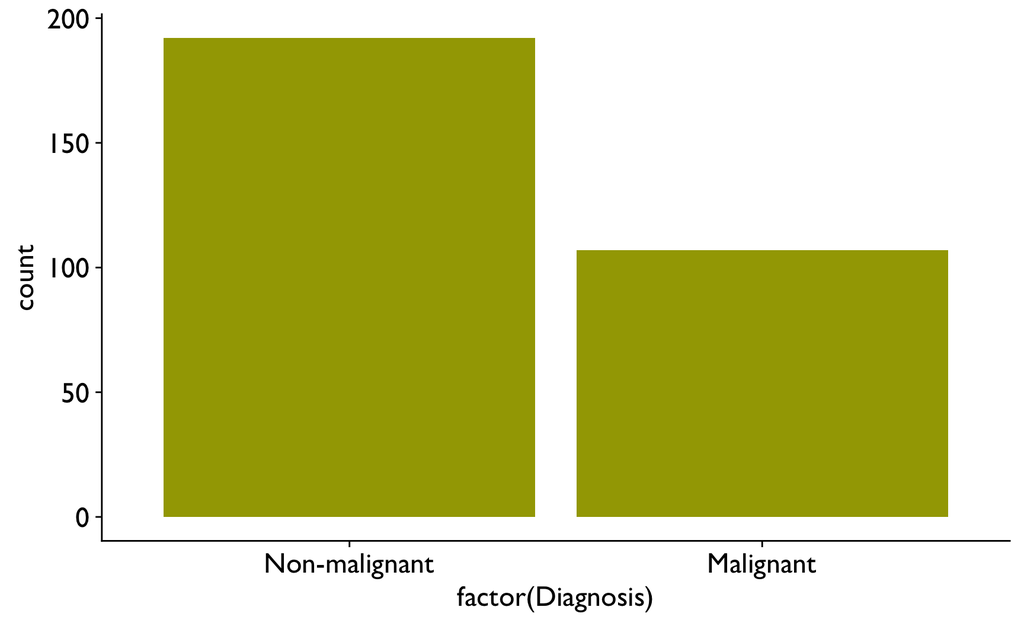

```r
# bar plot of the number of participants in each Diagnosis group
ggplot(Cancer, aes(x = factor(Diagnosis))) + geom_bar()
```

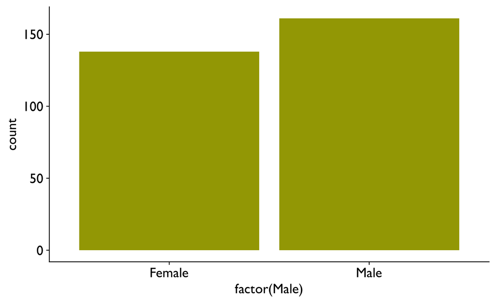

```r
# bar plot of the number of participants in each sex group
ggplot(Cancer, aes(x = factor(Male))) + geom_bar()
```